# Experiment 2 Paper

# Reanalysis of Experiment 1 data

## Question 1: Do tests cognitive skills discriminate participants well (i.e., do we have a wide range of scores)?

We get ceiling effects for CCPT (see also descriptive stats below), so we do not use this measure in further analyses.

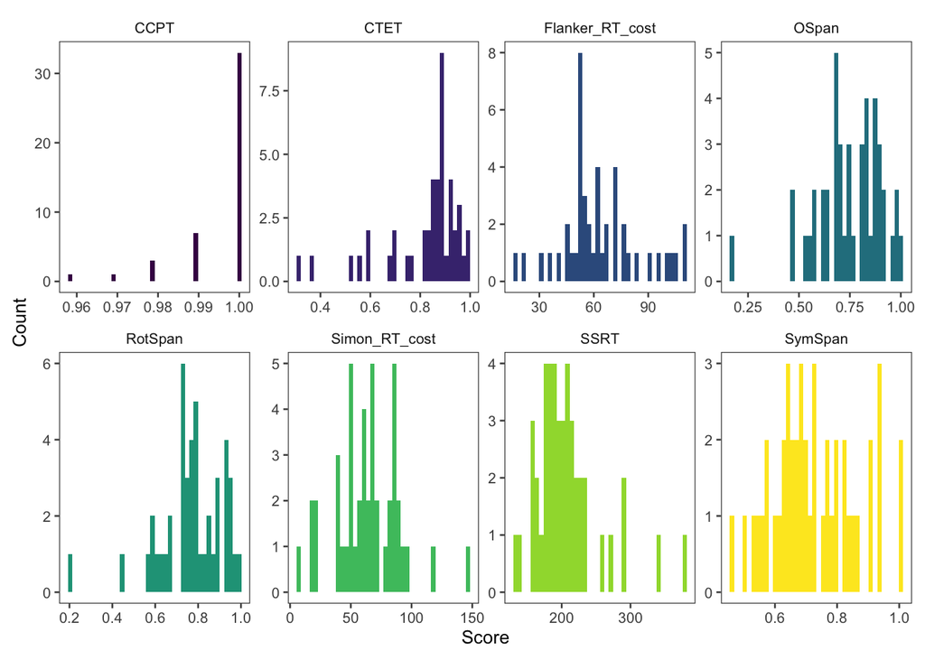

## 1a: Descriptive statistics of cognitive measures

| Measure | mean | sd |
| --- | --- | --- |
| CCPT | 1.00 | 0.01 |
| CTET | 0.82 | 0.15 |
| Flanker_RT_cost | 63.47 | 21.73 |
| OSpan | 0.75 | 0.16 |
| RotSpan | 0.77 | 0.15 |
| Simon_RT_cost | 63.95 | 26.62 |
| SSRT | 207.41 | 47.63 |
| SymSpan | 0.73 | 0.13 |

## 1b: Do cognitive skills correlate with each other?

|  | Flanker_RT_cost | Simon_RT_cost | CTET | OSpan | SymSpan | RotSpan | SSRT |
| --- | --- | --- | --- | --- | --- | --- | --- |
| Flanker_RT_cost | 1.00 | -.06 | -.06 | -.11 | -.14 | .04 | .16 |
| Simon_RT_cost | -.06 | 1.00 | -.02 | -.13 | -.12 | -.06 | -.03 |
| CTET | -.06 | -.02 | 1.00 | .03 | .17 | .10 | -.25 |
| OSpan | -.11 | -.13 | .03 | 1.00 | .33 | .33 | -.22 |
| SymSpan | -.14 | -.12 | .17 | .33 | 1.00 | .39 | -.31 |
| RotSpan | .04 | -.06 | .10 | .33 | .39 | 1.00 | -.13 |
| SSRT | .16 | -.03 | -.25 | -.22 | -.31 | -.13 | 1.00 |

## Question 2: Do cognitive skills correlate with ex-gaussian parameters of RT distribution (baseline condition only)?

Mean and credible intervals of posterior distributions

| Parameter | Mean | CI | CI_low | CI_high | pd | ROPE_CI | ROPE_low | ROPE_high | ROPE_Percentage | Prior_Distribution | Prior_Location | Prior_Scale | var1 | exgaus_par |
| --- | --- | --- | --- | --- | --- | --- | --- | --- | --- | --- | --- | --- | --- | --- |
| rho | -0.0545840 | 0.95 | -0.3317120 | 0.2078489 | 0.64575 | 0.95 | -0.05 | 0.05 | 0.2709813 | beta | 3 | 3 | Flanker_RT_cost | mu |
| rho | 0.0948903 | 0.95 | -0.1789855 | 0.3682551 | 0.75275 | 0.95 | -0.05 | 0.05 | 0.2244146 | beta | 3 | 3 | Simon_RT_cost | mu |
| rho | -0.2639651 | 0.95 | -0.5253053 | -0.0155742 | 0.97575 | 0.95 | -0.05 | 0.05 | 0.0281505 | beta | 3 | 3 | CTET | mu |
| rho | -0.0677039 | 0.95 | -0.3289212 | 0.2085749 | 0.68450 | 0.95 | -0.05 | 0.05 | 0.2512497 | beta | 3 | 3 | OSpan | mu |
| rho | -0.1208240 | 0.95 | -0.3994610 | 0.1219774 | 0.81725 | 0.95 | -0.05 | 0.05 | 0.2099448 | beta | 3 | 3 | SymSpan | mu |
| rho | -0.1260608 | 0.95 | -0.3899187 | 0.1598459 | 0.82000 | 0.95 | -0.05 | 0.05 | 0.1907393 | beta | 3 | 3 | RotSpan | mu |
| rho | 0.1300439 | 0.95 | -0.1395596 | 0.3903176 | 0.82725 | 0.95 | -0.05 | 0.05 | 0.1902131 | beta | 3 | 3 | SSRT | mu |
| rho | 0.0124793 | 0.95 | -0.2622298 | 0.2740146 | 0.53850 | 0.95 | -0.05 | 0.05 | 0.2865036 | beta | 3 | 3 | Flanker_RT_cost | sigma |
| rho | 0.0428164 | 0.95 | -0.2309236 | 0.3085078 | 0.62425 | 0.95 | -0.05 | 0.05 | 0.2691397 | beta | 3 | 3 | Simon_RT_cost | sigma |
| rho | -0.1743344 | 0.95 | -0.4379506 | 0.0901294 | 0.90375 | 0.95 | -0.05 | 0.05 | 0.1304920 | beta | 3 | 3 | CTET | sigma |
| rho | -0.0764634 | 0.95 | -0.3514021 | 0.1817041 | 0.71150 | 0.95 | -0.05 | 0.05 | 0.2457248 | beta | 3 | 3 | OSpan | sigma |
| rho | 0.0189339 | 0.95 | -0.2587136 | 0.2834326 | 0.55750 | 0.95 | -0.05 | 0.05 | 0.2836096 | beta | 3 | 3 | SymSpan | sigma |
| rho | -0.3620791 | 0.95 | -0.6085072 | -0.1249892 | 0.99275 | 0.95 | -0.05 | 0.05 | 0.0000000 | beta | 3 | 3 | RotSpan | sigma |
| rho | 0.3638932 | 0.95 | 0.1286990 | 0.5923669 | 0.99825 | 0.95 | -0.05 | 0.05 | 0.0000000 | beta | 3 | 3 | SSRT | sigma |
| rho | 0.1467899 | 0.95 | -0.1328389 | 0.3989659 | 0.85500 | 0.95 | -0.05 | 0.05 | 0.1607472 | beta | 3 | 3 | Flanker_RT_cost | tau |
| rho | 0.0377958 | 0.95 | -0.2406625 | 0.3145147 | 0.61150 | 0.95 | -0.05 | 0.05 | 0.2838727 | beta | 3 | 3 | Simon_RT_cost | tau |
| rho | -0.1741104 | 0.95 | -0.4227594 | 0.0883767 | 0.90450 | 0.95 | -0.05 | 0.05 | 0.1357537 | beta | 3 | 3 | CTET | tau |
| rho | 0.0055314 | 0.95 | -0.2607543 | 0.2853751 | 0.51150 | 0.95 | -0.05 | 0.05 | 0.2872928 | beta | 3 | 3 | OSpan | tau |
| rho | 0.2135676 | 0.95 | -0.0570033 | 0.4668600 | 0.93475 | 0.95 | -0.05 | 0.05 | 0.0868193 | beta | 3 | 3 | SymSpan | tau |
| rho | -0.0046568 | 0.95 | -0.2739097 | 0.2709486 | 0.50875 | 0.95 | -0.05 | 0.05 | 0.2788740 | beta | 3 | 3 | RotSpan | tau |
| rho | 0.1213370 | 0.95 | -0.1543968 | 0.3830465 | 0.81000 | 0.95 | -0.05 | 0.05 | 0.2059984 | beta | 3 | 3 | SSRT | tau |

Bayes factors in favor of the alternative hypothesis

| bf | error | var1 | exgaus_par |
| --- | --- | --- | --- |
| 0.3617537 | 0 | Flanker_RT_cost | mu |
| 0.4222558 | 0 | Simon_RT_cost | mu |
| 2.1694443 | 0 | CTET | mu |
| 0.3719821 | 0 | OSpan | mu |
| 0.4894395 | 0 | SymSpan | mu |
| 0.5126061 | 0 | RotSpan | mu |
| 0.5366335 | 0 | SSRT | mu |
| 0.3357950 | 0 | Flanker_RT_cost | sigma |
| 0.3520255 | 0 | Simon_RT_cost | sigma |
| 0.7506561 | 0 | CTET | sigma |
| 0.3863029 | 0 | OSpan | sigma |
| 0.3368456 | 0 | SymSpan | sigma |
| 12.7763722 | 0 | RotSpan | sigma |
| 11.5210113 | 0 | SSRT | sigma |
| 0.5993976 | 0 | Flanker_RT_cost | tau |
| 0.3489495 | 0 | Simon_RT_cost | tau |
| 0.7452144 | 0 | CTET | tau |
| 0.3345227 | 0 | OSpan | tau |
| 1.0921292 | 0 | SymSpan | tau |
| 0.3340459 | 0 | RotSpan | tau |
| 0.4820256 | 0 | SSRT | tau |

# Experiment 2 data

## Question 1: Replicate reanalysis of Exp. 1 in a hypothesis-driven way (using slow block only)

Histogram of scores. They look pretty similar to Experiment 1. (The participant with the really low CCPT hit rate was not the same person with low scores on other tasks.)

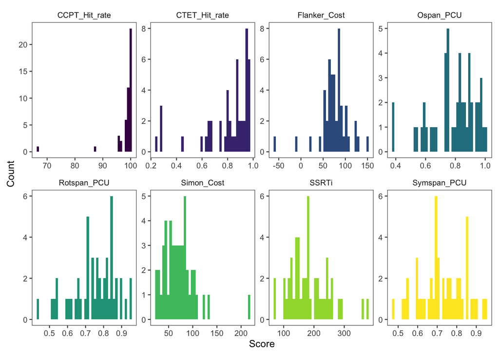

Mean and credible intervals of posterior distribution

| Parameter | Mean | CI | CI_low | CI_high | pd | ROPE_CI | ROPE_low | ROPE_high | ROPE_Percentage | Prior_Distribution | Prior_Location | Prior_Scale | var1 | exgaus_par |
| --- | --- | --- | --- | --- | --- | --- | --- | --- | --- | --- | --- | --- | --- | --- |
| rho | 0.1143044 | 0.95 | -0.1426926 | 0.3860915 | 0.80100 | 0.95 | -0.05 | 0.05 | 0.2086293 | beta | 3 | 3 | Ospan_PCU | mu |
| rho | -0.0362719 | 0.95 | -0.2961431 | 0.2361468 | 0.59975 | 0.95 | -0.05 | 0.05 | 0.2833465 | beta | 3 | 3 | Symspan_PCU | mu |
| rho | 0.0939570 | 0.95 | -0.1770072 | 0.3487437 | 0.75875 | 0.95 | -0.05 | 0.05 | 0.2433570 | beta | 3 | 3 | Rotspan_PCU | mu |
| rho | -0.1254337 | 0.95 | -0.3979879 | 0.1182319 | 0.81700 | 0.95 | -0.05 | 0.05 | 0.2041568 | beta | 3 | 3 | CTET_Hit_rate | mu |
| rho | -0.1926114 | 0.95 | -0.4479794 | 0.0642448 | 0.92300 | 0.95 | -0.05 | 0.05 | 0.1112865 | beta | 3 | 3 | Flanker_Cost | mu |
| rho | 0.0125679 | 0.95 | -0.2491993 | 0.2725428 | 0.53475 | 0.95 | -0.05 | 0.05 | 0.3038674 | beta | 3 | 3 | Simon_Cost | mu |
| rho | 0.0180342 | 0.95 | -0.2414044 | 0.2952030 | 0.56400 | 0.95 | -0.05 | 0.05 | 0.3022889 | beta | 3 | 3 | SSRTi | mu |
| rho | -0.3017654 | 0.95 | -0.5362111 | -0.0476288 | 0.98725 | 0.95 | -0.05 | 0.05 | 0.0026309 | beta | 3 | 3 | Ospan_PCU | sigma |
| rho | -0.0408667 | 0.95 | -0.3040034 | 0.2189504 | 0.62500 | 0.95 | -0.05 | 0.05 | 0.2867666 | beta | 3 | 3 | Symspan_PCU | sigma |
| rho | -0.0344730 | 0.95 | -0.3256355 | 0.2086027 | 0.60775 | 0.95 | -0.05 | 0.05 | 0.2757169 | beta | 3 | 3 | Rotspan_PCU | sigma |
| rho | -0.0500863 | 0.95 | -0.2957502 | 0.2310278 | 0.64750 | 0.95 | -0.05 | 0.05 | 0.2741384 | beta | 3 | 3 | CTET_Hit_rate | sigma |
| rho | -0.0570329 | 0.95 | -0.3281818 | 0.1804837 | 0.65650 | 0.95 | -0.05 | 0.05 | 0.2733491 | beta | 3 | 3 | Flanker_Cost | sigma |
| rho | 0.0888073 | 0.95 | -0.1652547 | 0.3440857 | 0.74625 | 0.95 | -0.05 | 0.05 | 0.2486188 | beta | 3 | 3 | Simon_Cost | sigma |
| rho | 0.2677708 | 0.95 | 0.0226484 | 0.5218664 | 0.98000 | 0.95 | -0.05 | 0.05 | 0.0220994 | beta | 3 | 3 | SSRTi | sigma |
| rho | -0.2087059 | 0.95 | -0.4683781 | 0.0419671 | 0.93700 | 0.95 | -0.05 | 0.05 | 0.0944488 | beta | 3 | 3 | Ospan_PCU | tau |
| rho | 0.1032406 | 0.95 | -0.1434379 | 0.3760845 | 0.78700 | 0.95 | -0.05 | 0.05 | 0.2299395 | beta | 3 | 3 | Symspan_PCU | tau |
| rho | -0.0974958 | 0.95 | -0.3642918 | 0.1757634 | 0.75900 | 0.95 | -0.05 | 0.05 | 0.2173112 | beta | 3 | 3 | Rotspan_PCU | tau |
| rho | 0.0386757 | 0.95 | -0.2386351 | 0.2850547 | 0.60650 | 0.95 | -0.05 | 0.05 | 0.2694028 | beta | 3 | 3 | CTET_Hit_rate | tau |
| rho | 0.0004915 | 0.95 | -0.2861669 | 0.2631000 | 0.50225 | 0.95 | -0.05 | 0.05 | 0.2946593 | beta | 3 | 3 | Flanker_Cost | tau |
| rho | 0.1836318 | 0.95 | -0.0439395 | 0.4617044 | 0.92000 | 0.95 | -0.05 | 0.05 | 0.1249671 | beta | 3 | 3 | Simon_Cost | tau |
| rho | 0.1492739 | 0.95 | -0.1074195 | 0.4081044 | 0.85775 | 0.95 | -0.05 | 0.05 | 0.1636411 | beta | 3 | 3 | SSRTi | tau |

Bayes factors in favor of the alternative hypothesis

| bf | error | var1 | exgaus_par |
| --- | --- | --- | --- |
| 0.4696561 | 0 | Ospan_PCU | mu |
| 0.3370777 | 0 | Symspan_PCU | mu |
| 0.4152347 | 0 | Rotspan_PCU | mu |
| 0.5049893 | 0 | CTET_Hit_rate | mu |
| 0.8665235 | 0 | Flanker_Cost | mu |
| 0.3253701 | 0 | Simon_Cost | mu |
| 0.3272054 | 0 | SSRTi | mu |
| 4.2580620 | 0 | Ospan_PCU | sigma |
| 0.3381634 | 0 | Symspan_PCU | sigma |
| 0.3397510 | 0 | Rotspan_PCU | sigma |
| 0.3464938 | 0 | CTET_Hit_rate | sigma |
| 0.3578566 | 0 | Flanker_Cost | sigma |
| 0.3979636 | 0 | Simon_Cost | sigma |
| 2.5533095 | 0 | SSRTi | sigma |
| 1.0865464 | 0 | Ospan_PCU | tau |
| 0.4298397 | 0 | Symspan_PCU | tau |
| 0.4202881 | 0 | Rotspan_PCU | tau |
| 0.3393048 | 0 | CTET_Hit_rate | tau |
| 0.3243196 | 0 | Flanker_Cost | tau |
| 0.8016568 | 0 | Simon_Cost | tau |
| 0.6101374 | 0 | SSRTi | tau |

## Question 2: Do we see stronger relationships between cog. skills and word production speed when the task is more difficult (speeded task)?

Mean and credible intervals of posterior distribution

| Parameter | Mean | CI | CI_low | CI_high | pd | ROPE_CI | ROPE_low | ROPE_high | ROPE_Percentage | Prior_Distribution | Prior_Location | Prior_Scale | var1 | exgaus_par |
| --- | --- | --- | --- | --- | --- | --- | --- | --- | --- | --- | --- | --- | --- | --- |
| rho | 0.0783766 | 0.95 | -0.2018568 | 0.3186209 | 0.71575 | 0.95 | -0.05 | 0.05 | 0.2517758 | beta | 3 | 3 | Ospan_PCU | mu |
| rho | 0.0073288 | 0.95 | -0.2475935 | 0.2747893 | 0.51300 | 0.95 | -0.05 | 0.05 | 0.3033412 | beta | 3 | 3 | Symspan_PCU | mu |
| rho | 0.0357489 | 0.95 | -0.2418889 | 0.2903715 | 0.60775 | 0.95 | -0.05 | 0.05 | 0.2788740 | beta | 3 | 3 | Rotspan_PCU | mu |
| rho | -0.1650916 | 0.95 | -0.4284767 | 0.0831303 | 0.89375 | 0.95 | -0.05 | 0.05 | 0.1402263 | beta | 3 | 3 | CTET_Hit_rate | mu |
| rho | -0.0301058 | 0.95 | -0.2945054 | 0.2465104 | 0.59025 | 0.95 | -0.05 | 0.05 | 0.2788740 | beta | 3 | 3 | Flanker_Cost | mu |
| rho | 0.1638378 | 0.95 | -0.1049890 | 0.4259593 | 0.88275 | 0.95 | -0.05 | 0.05 | 0.1407524 | beta | 3 | 3 | Simon_Cost | mu |
| rho | -0.0711337 | 0.95 | -0.3353857 | 0.1919245 | 0.69650 | 0.95 | -0.05 | 0.05 | 0.2744015 | beta | 3 | 3 | SSRTi | mu |
| rho | -0.2667792 | 0.95 | -0.5057611 | -0.0020296 | 0.97375 | 0.95 | -0.05 | 0.05 | 0.0247303 | beta | 3 | 3 | Ospan_PCU | sigma |
| rho | -0.0174049 | 0.95 | -0.2951177 | 0.2322670 | 0.55025 | 0.95 | -0.05 | 0.05 | 0.2920284 | beta | 3 | 3 | Symspan_PCU | sigma |
| rho | 0.0325066 | 0.95 | -0.2270073 | 0.3005341 | 0.59950 | 0.95 | -0.05 | 0.05 | 0.2938700 | beta | 3 | 3 | Rotspan_PCU | sigma |
| rho | 0.0583780 | 0.95 | -0.2145319 | 0.3096182 | 0.66425 | 0.95 | -0.05 | 0.05 | 0.2678243 | beta | 3 | 3 | CTET_Hit_rate | sigma |
| rho | 0.0542500 | 0.95 | -0.2278328 | 0.3027209 | 0.65825 | 0.95 | -0.05 | 0.05 | 0.2786109 | beta | 3 | 3 | Flanker_Cost | sigma |
| rho | 0.1338402 | 0.95 | -0.1401568 | 0.3755381 | 0.84250 | 0.95 | -0.05 | 0.05 | 0.1849513 | beta | 3 | 3 | Simon_Cost | sigma |
| rho | 0.0452652 | 0.95 | -0.2268796 | 0.2954995 | 0.63400 | 0.95 | -0.05 | 0.05 | 0.2843988 | beta | 3 | 3 | SSRTi | sigma |
| rho | -0.0232209 | 0.95 | -0.2858604 | 0.2302103 | 0.55675 | 0.95 | -0.05 | 0.05 | 0.2972902 | beta | 3 | 3 | Ospan_PCU | tau |
| rho | 0.0906638 | 0.95 | -0.1821863 | 0.3457978 | 0.74800 | 0.95 | -0.05 | 0.05 | 0.2365167 | beta | 3 | 3 | Symspan_PCU | tau |
| rho | -0.0127157 | 0.95 | -0.2728259 | 0.2710455 | 0.53525 | 0.95 | -0.05 | 0.05 | 0.2991318 | beta | 3 | 3 | Rotspan_PCU | tau |
| rho | 0.1240262 | 0.95 | -0.1245056 | 0.4013418 | 0.82100 | 0.95 | -0.05 | 0.05 | 0.2015259 | beta | 3 | 3 | CTET_Hit_rate | tau |
| rho | -0.1391527 | 0.95 | -0.4066327 | 0.1148486 | 0.84875 | 0.95 | -0.05 | 0.05 | 0.1828466 | beta | 3 | 3 | Flanker_Cost | tau |
| rho | 0.1234398 | 0.95 | -0.1432880 | 0.3865273 | 0.82125 | 0.95 | -0.05 | 0.05 | 0.2036306 | beta | 3 | 3 | Simon_Cost | tau |
| rho | 0.1568764 | 0.95 | -0.1031283 | 0.4146812 | 0.87700 | 0.95 | -0.05 | 0.05 | 0.1520652 | beta | 3 | 3 | SSRTi | tau |

Bayes factors in favor of the alternative hypothesis: We really don’t have evidence for anything (no evidence for correlations or for null)

| bf | error | var1 | exgaus_par |
| --- | --- | --- | --- |
| 0.3825135 | 0 | Ospan_PCU | mu |
| 0.3246626 | 0 | Symspan_PCU | mu |
| 0.3362906 | 0 | Rotspan_PCU | mu |
| 0.7155860 | 0 | CTET_Hit_rate | mu |
| 0.3323345 | 0 | Flanker_Cost | mu |
| 0.6618182 | 0 | Simon_Cost | mu |
| 0.3733666 | 0 | SSRTi | mu |
| 2.4761296 | 0 | Ospan_PCU | sigma |
| 0.3271687 | 0 | Symspan_PCU | sigma |
| 0.3360800 | 0 | Rotspan_PCU | sigma |
| 0.3532696 | 0 | CTET_Hit_rate | sigma |
| 0.3494307 | 0 | Flanker_Cost | sigma |
| 0.5264806 | 0 | Simon_Cost | sigma |
| 0.3447734 | 0 | SSRTi | sigma |
| 0.3286258 | 0 | Ospan_PCU | tau |
| 0.4036595 | 0 | Symspan_PCU | tau |
| 0.3251054 | 0 | Rotspan_PCU | tau |
| 0.4913260 | 0 | CTET_Hit_rate | tau |
| 0.5489066 | 0 | Flanker_Cost | tau |
| 0.4823891 | 0 | Simon_Cost | tau |
| 0.6650139 | 0 | SSRTi | tau |

## Question 3: Do participants show smaller semantic interference effects when we force them to respond faster?

It doesn’t look like it. We didn’t get an interaction between speed block and condition. There was an interaction between the semantic interference effect and block order, but the effect was significant for both block orders, just larger in the participants who got the fast block first (which seems counterintuitive).

I then ran the models without block order.

```r
df5 <- df5 %>%
  mutate(block_order = case_when(
  Type_Presentation %in% c(4002,4004) ~ "fast_first",
  Type_Presentation %in% c(4001,4003) ~ "normal_first",
  )
)

df5_sem <- droplevels(subset(df5, Condition %in% c("sem.unr","sem.rel")))
contrasts(df5_sem$Condition) <- rbind(-.5,.5)
df5_sem$block_order <- as.factor(df5_sem$block_order)
contrasts(df5_sem$block_order) <- rbind(-.5,.5)
df5_sem$Speed <- as.factor(df5_sem$Speed)
contrasts(df5_sem$Speed) <- rbind(-.5,.5)

m0 <- lmer(RT~Speed+Condition+block_order+(1|Picture)+(1|Participant_ID), data=df5_sem)
mat_trt <- model.matrix(m0)
head(mat_trt)
```

```
##    (Intercept) Speed1 Condition1 block_order1
## 1            1    0.5        0.5          0.5
## 5            1    0.5       -0.5          0.5
## 6            1    0.5        0.5          0.5
## 10           1    0.5       -0.5          0.5
## 11           1    0.5        0.5          0.5
## 15           1    0.5       -0.5          0.5
```

```r
df5_sem$Speed.cont <- mat_trt[,2]
df5_sem$Condition.cont <- mat_trt[,3]
df5_sem$block_order.cont <- mat_trt[,4]

m1 <- lmer(RT~Speed.cont*Condition.cont*block_order.cont + (1+Speed.cont*Condition.cont*block_order.cont||Picture)+(1+Speed.cont*Condition.cont||Participant_ID), data = df5_sem)

m1b <- lmer(RT~Speed.cont*Condition.cont*block_order.cont + (1+Speed.cont*Condition.cont*block_order.cont||Picture)+(1+Speed.cont*Condition.cont||Participant_ID), data = df5_sem[abs(scale(resid(m1)))<2.5,])
print(summary(m1b, corr=F))
```

```
## Linear mixed model fit by REML. t-tests use Satterthwaite's method [
## lmerModLmerTest]
## Formula:
## RT ~ Speed.cont * Condition.cont * block_order.cont + (1 + Speed.cont *
##     Condition.cont * block_order.cont || Picture) + (1 + Speed.cont *
##     Condition.cont || Participant_ID)
##    Data: df5_sem[abs(scale(resid(m1))) < 2.5, ]
##
## REML criterion at convergence: 95193.5
##
## Scaled residuals:
##     Min      1Q  Median      3Q     Max
## -2.4775 -0.6572 -0.1662  0.4561  3.5307
##
## Random effects:
##  Groups           Name                                       Variance
##  Picture          (Intercept)                                2.298e+03
##  Picture.1        Speed.cont                                 1.060e+02
##  Picture.2        Condition.cont                             2.870e+03
##  Picture.3        block_order.cont                           2.476e+02
##  Picture.4        Speed.cont:Condition.cont                  6.511e-06
##  Picture.5        Speed.cont:block_order.cont                4.967e-04
##  Picture.6        Condition.cont:block_order.cont            0.000e+00
##  Picture.7        Speed.cont:Condition.cont:block_order.cont 2.503e+03
##  Participant_ID   (Intercept)                                5.531e+03
##  Participant_ID.1 Speed.cont                                 8.243e+02
##  Participant_ID.2 Condition.cont                             2.191e+02
##  Participant_ID.3 Speed.cont:Condition.cont                  0.000e+00
##  Residual                                                    1.626e+04
##  Std.Dev.
##  4.793e+01
##  1.030e+01
##  5.357e+01
##  1.573e+01
##  2.552e-03
##  2.229e-02
##  0.000e+00
##  5.003e+01
##  7.437e+01
##  2.871e+01
```

[output cut: 13 more lines]

```
## Condition.cont:block_order.cont              17.385      7.281   45.693   2.388
## Speed.cont:Condition.cont:block_order.cont    1.897     12.916   84.092   0.147
##                                            Pr(>|t|)
## (Intercept)                                 < 2e-16 ***
## Speed.cont                                 9.29e-06 ***
## Condition.cont                             1.76e-06 ***
## block_order.cont                             0.2016
## Speed.cont:Condition.cont                    0.8520
## Speed.cont:block_order.cont                  0.1465
## Condition.cont:block_order.cont              0.0211 *
## Speed.cont:Condition.cont:block_order.cont   0.8836
## ---
## Signif. codes:  0 '***' 0.001 '**' 0.01 '*' 0.05 '.' 0.1 ' ' 1
## convergence code: 0
## boundary (singular) fit: see ?isSingular
```

```r
m1c <- lmer(RT~block_order/(Speed.cont*Condition.cont) + (1+block_order.cont/(Speed.cont*Condition.cont)||Picture)+(1+Speed.cont*Condition.cont||Participant_ID), data = df5_sem[abs(scale(resid(m1)))<2.5,])
print(summary(m1c, corr=F))
```

```
## Linear mixed model fit by REML. t-tests use Satterthwaite's method [
## lmerModLmerTest]
## Formula:
## RT ~ block_order/(Speed.cont * Condition.cont) + (1 + block_order.cont/(Speed.cont *
##     Condition.cont) || Picture) + (1 + Speed.cont * Condition.cont ||
##     Participant_ID)
##    Data: df5_sem[abs(scale(resid(m1))) < 2.5, ]
##
## REML criterion at convergence: 95373
##
## Scaled residuals:
##     Min      1Q  Median      3Q     Max
## -2.5843 -0.6670 -0.1716  0.4595  3.8902
##
## Random effects:
##  Groups           Name                                       Variance
##  Picture          (Intercept)                                2.238e+03
##  Picture.1        block_order.cont                           2.372e+02
##  Picture.2        block_order.cont:Speed.cont                4.515e-06
##  Picture.3        block_order.cont:Condition.cont            3.599e-05
##  Picture.4        block_order.cont:Speed.cont:Condition.cont 2.019e+03
##  Participant_ID   (Intercept)                                5.485e+03
##  Participant_ID.1 Speed.cont                                 7.916e+02
##  Participant_ID.2 Condition.cont                             2.017e+02
##  Participant_ID.3 Speed.cont:Condition.cont                  3.195e-06
##  Residual                                                    1.702e+04
##  Std.Dev.
##  4.731e+01
##  1.540e+01
##  2.125e-03
##  5.999e-03
##  4.493e+01
##  7.406e+01
##  2.814e+01
##  1.420e+01
##  1.788e-03
##  1.305e+02
## Number of obs: 7545, groups:  Picture, 90; Participant_ID, 48
##
## Fixed effects:
##                                                   Estimate Std. Error       df
## (Intercept)                                       771.0841    11.8927  65.8670
## block_order1                                      -28.2222    21.6533  46.4988
## block_orderfast_first:Speed.cont                   33.2875     7.1629  45.2410
## block_ordernormal_first:Speed.cont                 18.6508     7.1476  44.8239
## block_orderfast_first:Condition.cont              -42.7202     5.1646  46.0012
## block_ordernormal_first:Condition.cont            -24.7314     5.1437  45.1433
## block_orderfast_first:Speed.cont:Condition.cont    -0.7079     8.8674 292.7462
## block_ordernormal_first:Speed.cont:Condition.cont   1.8533     8.8126 285.3914
##                                                   t value Pr(>|t|)
## (Intercept)                                        64.837  < 2e-16 ***
## block_order1                                       -1.303   0.1989
## block_orderfast_first:Speed.cont                    4.647 2.92e-05 ***
## block_ordernormal_first:Speed.cont                  2.609   0.0123 *
## block_orderfast_first:Condition.cont               -8.272 1.18e-10 ***
## block_ordernormal_first:Condition.cont             -4.808 1.73e-05 ***
## block_orderfast_first:Speed.cont:Condition.cont    -0.080   0.9364
## block_ordernormal_first:Speed.cont:Condition.cont   0.210   0.8336
## ---
## Signif. codes:  0 '***' 0.001 '**' 0.01 '*' 0.05 '.' 0.1 ' ' 1
## convergence code: 0
## boundary (singular) fit: see ?isSingular
```

```r
m2 <- lmer(RT~Speed.cont*Condition.cont + (1+Speed.cont*Condition.cont||Picture)+(1+Speed.cont*Condition.cont||Participant_ID), data = df5_sem)

m2b <- lmer(RT~Speed.cont*Condition.cont + (1+Speed.cont*Condition.cont||Picture)+(1+Speed.cont*Condition.cont||Participant_ID), data = df5_sem[abs(scale(resid(m2)))<2.5,])
print(summary(m2b, corr=F))
```

```
## Linear mixed model fit by REML. t-tests use Satterthwaite's method [
## lmerModLmerTest]
## Formula:
## RT ~ Speed.cont * Condition.cont + (1 + Speed.cont * Condition.cont ||
##     Picture) + (1 + Speed.cont * Condition.cont || Participant_ID)
##    Data: df5_sem[abs(scale(resid(m2))) < 2.5, ]
##
## REML criterion at convergence: 95218.9
##
## Scaled residuals:
##     Min      1Q  Median      3Q     Max
## -2.4869 -0.6587 -0.1738  0.4553  3.7663
##
## Random effects:
##  Groups           Name                      Variance  Std.Dev.
##  Picture          (Intercept)               2.307e+03 4.803e+01
##  Picture.1        Speed.cont                7.966e+01 8.925e+00
##  Picture.2        Condition.cont            2.911e+03 5.395e+01
##  Picture.3        Speed.cont:Condition.cont 1.840e-05 4.289e-03
##  Participant_ID   (Intercept)               5.640e+03 7.510e+01
##  Participant_ID.1 Speed.cont                8.443e+02 2.906e+01
##  Participant_ID.2 Condition.cont            2.655e+02 1.630e+01
##  Participant_ID.3 Speed.cont:Condition.cont 3.311e-05 5.754e-03
##  Residual                                   1.636e+04 1.279e+02
## Number of obs: 7544, groups:  Picture, 90; Participant_ID, 48
##
## Fixed effects:
##                           Estimate Std. Error       df t value Pr(>|t|)
## (Intercept)                771.582     12.055   67.364  64.004  < 2e-16 ***
## Speed.cont                  26.286      5.218   45.986   5.037 7.77e-06 ***
## Condition.cont             -34.190      6.831   92.454  -5.005 2.65e-06 ***
## Speed.cont:Condition.cont    1.283      5.906 7173.298   0.217    0.828
## ---
## Signif. codes:  0 '***' 0.001 '**' 0.01 '*' 0.05 '.' 0.1 ' ' 1
## convergence code: 0
## boundary (singular) fit: see ?isSingular
```

## Question 4: Does attention interact with the semantic interference effect?

```r
m3 <- lmer(RT~Condition.cont*CTET_Hit_rate + (1+Condition.cont*CTET_Hit_rate||Picture)+(1+Condition.cont*CTET_Hit_rate||Participant_ID), data = df5_sem)

m3b <- lmer(RT~Condition.cont*CTET_Hit_rate + (1+Condition.cont*CTET_Hit_rate||Picture)+(1+Condition.cont*CTET_Hit_rate||Participant_ID), data = df5_sem[abs(scale(resid(m3)))<2.5,])
print(summary(m3b, corr=F))
```

```
## Linear mixed model fit by REML. t-tests use Satterthwaite's method [
## lmerModLmerTest]
## Formula:
## RT ~ Condition.cont * CTET_Hit_rate + (1 + Condition.cont * CTET_Hit_rate ||
##     Picture) + (1 + Condition.cont * CTET_Hit_rate || Participant_ID)
##    Data: df5_sem[abs(scale(resid(m3))) < 2.5, ]
##
## REML criterion at convergence: 95386.2
##
## Scaled residuals:
##     Min      1Q  Median      3Q     Max
## -2.5204 -0.6624 -0.1603  0.4627  3.7350
##
## Random effects:
##  Groups           Name                         Variance  Std.Dev.
##  Picture          (Intercept)                  2.307e+03  48.03451
##  Picture.1        Condition.cont               1.567e+03  39.59149
##  Picture.2        CTET_Hit_rate                0.000e+00   0.00000
##  Picture.3        Condition.cont:CTET_Hit_rate 2.019e+03  44.93784
##  Participant_ID   (Intercept)                  1.567e+03  39.58207
##  Participant_ID.1 Condition.cont               2.302e+02  15.17392
##  Participant_ID.2 CTET_Hit_rate                6.007e+03  77.50252
##  Participant_ID.3 Condition.cont:CTET_Hit_rate 7.404e-04   0.02721
##  Residual                                      1.680e+04 129.62340
## Number of obs: 7547, groups:  Picture, 90; Participant_ID, 48
##
## Fixed effects:
##                              Estimate Std. Error      df t value Pr(>|t|)
## (Intercept)                   756.821     31.122   8.108  24.318 7.24e-09 ***
## Condition.cont                -43.490     16.139  51.236  -2.695  0.00951 **
## CTET_Hit_rate                  19.983     40.906  13.052   0.489  0.63330
## Condition.cont:CTET_Hit_rate   10.529     19.515  49.886   0.540  0.59190
## ---
## Signif. codes:  0 '***' 0.001 '**' 0.01 '*' 0.05 '.' 0.1 ' ' 1
## convergence code: 0
## boundary (singular) fit: see ?isSingular
```

## Question 5: Does distractor recall predict the magnitude of the semantic interference effect?

```r
m4 <- lmer(RT~Condition.cont*D_prime_Recall_Participant + (1+Condition.cont*D_prime_Recall_Participant||Picture)+(1+Condition.cont*D_prime_Recall_Participant||Participant_ID), data = df5_sem)

m4b <- lmer(RT~Condition.cont*D_prime_Recall_Participant + (1+Condition.cont*D_prime_Recall_Participant||Picture)+(1+Condition.cont*D_prime_Recall_Participant||Participant_ID), data = df5_sem[abs(scale(resid(m4)))<2.5,])
print(summary(m4b, corr=F))
```

```
## Linear mixed model fit by REML. t-tests use Satterthwaite's method [
## lmerModLmerTest]
## Formula:
## RT ~ Condition.cont * D_prime_Recall_Participant + (1 + Condition.cont *
##     D_prime_Recall_Participant || Picture) + (1 + Condition.cont *
##     D_prime_Recall_Participant || Participant_ID)
##    Data: df5_sem[abs(scale(resid(m4))) < 2.5, ]
##
## REML criterion at convergence: 95421.7
##
## Scaled residuals:
##     Min      1Q  Median      3Q     Max
## -2.4949 -0.6632 -0.1600  0.4575  3.7122
##
## Random effects:
##  Groups           Name                                      Variance Std.Dev.
##  Picture          (Intercept)                                2333.37  48.305
##  Picture.1        Condition.cont                             2826.75  53.167
##  Picture.2        D_prime_Recall_Participant                    0.00   0.000
##  Picture.3        Condition.cont:D_prime_Recall_Participant     0.00   0.000
##  Participant_ID   (Intercept)                                5703.37  75.521
##  Participant_ID.1 Condition.cont                               81.88   9.049
##  Participant_ID.2 D_prime_Recall_Participant                    0.00   0.000
##  Participant_ID.3 Condition.cont:D_prime_Recall_Participant   283.77  16.845
##  Residual                                                   16846.07 129.792
## Number of obs: 7548, groups:  Picture, 90; Participant_ID, 48
##
## Fixed effects:
##                                           Estimate Std. Error      df t value
## (Intercept)                                783.070     20.110  52.470  38.939
## Condition.cont                             -34.739      8.607  36.293  -4.036
## D_prime_Recall_Participant                 -15.158     22.095  46.054  -0.686
## Condition.cont:D_prime_Recall_Participant   -1.319      8.340  23.671  -0.158
##                                           Pr(>|t|)
## (Intercept)                                < 2e-16 ***
## Condition.cont                            0.000269 ***
## D_prime_Recall_Participant                0.496135
## Condition.cont:D_prime_Recall_Participant 0.875638
## ---
## Signif. codes:  0 '***' 0.001 '**' 0.01 '*' 0.05 '.' 0.1 ' ' 1
## convergence code: 0
## boundary (singular) fit: see ?isSingular
```